# Annotating TCRs for Antigen Specificity

2023-09-01

## Overview

We previously generated a dataset of TCR beta chain (TRB) clonotypes of known antigen/epitope specificity that were collected from two resources; SARS-CoV-2 from [immuneCODE](https://clients.adaptivebiotech.com/pub/covid-2020) and various antigens from [VDJdb](https://vdjdb.cdr3.net/). These resources were parsed and wrangled into a format that we can use to merge with the 10x T cell data.

To annotate the clonotypes from our single cell data with antigen specificity we will rely of exact matches between the clonotype labels between the datasets; using V + J + CDR3AA sequence. It is not uncommon to use only the CDR3 or junction AA sequence as an alternative ‘complete’ clonotype matching.

The R markdown script for this workflow is available on [github](https://raw.githubusercontent.com/kjlj/scRNA-seq_VDJ/main/docs/antigen_annotation_T_cells.Rmd) in the [workshop respository](https://github.com/kjlj/scRNA-seq_VDJ).

## Setting up R session

### R packages

Using two packages; the [tidyverse collection](https://www.tidyverse.org/) for the data manipulation and [ggsci](https://cran.r-project.org/web/packages/ggsci/vignettes/ggsci.html) for colour palettes.

```r
#loading R packages
#tidyverse packages for data manipulation and plotting
#check if the package is already installed, if not, install it
if (sum(grepl("tidyverse", rownames(installed.packages()))) > 0) {
  print("tidyverse is already installed")
} else {
  install.packages("tidyverse")
}
```

```
## [1] "tidyverse is already installed"
```

```r
#loading R packages
library(tidyverse)
#ggsci for colour scales for scientific journals
#check if the package is already installed, if not, install it
if (sum(grepl("ggsci", rownames(installed.packages()))) > 0) {
  print("ggsci is already installed")
} else {
  install.packages("ggsci")
}
```

```
## [1] "ggsci is already installed"
```

```r
library(ggsci)
```

### Themes for ggplot2

Adding some custom ggplot2 themes for plotting:

```r
##themes for plots
theme_custom <- function (base_size = 12) {
  theme_bw(base_size=base_size) %+replace%
    theme(panel.grid = element_blank(),
          panel.border = element_blank(),
          axis.line = element_line(colour="black"),
          axis.text.x = element_text(colour="black", size=base_size),
          axis.text.y = element_text(colour="black", size = base_size, hjust = 1),
          axis.title = element_text(colour="black", face="bold", size = base_size),
          strip.background = element_blank(),
          strip.text = element_text(colour="black", face="bold", size=base_size),
          legend.text = element_text(colour="black", size=base_size)
    )
}

theme_x_rotated <- function (base_size = 12) {
  theme_custom(base_size=base_size) %+replace%
    theme(axis.text.x = element_text(colour="black", angle = 90, hjust = 1, vjust = 0.5, size=base_size))
}
```

## Loading datasets

There are two datasets to load. We will need the Seurat data and the antigen annotated TRB clonotypes.

To save on memory, we will load the Seurat metadata and UMAP coordinates from the tab-delimited file rather than the complete Suerat objects:

```r
# seurat dump that includes the UMAP coords & meta with VDJ
seurat.data <- read_tsv("~/Documents/GitHub/scRNA-seq_VDJ/data/pbmc-tumour_seruat_data.tsv")
#or, from URL from github
#seurat.data <- read_tsv("https://raw.githubusercontent.com/kjlj/scRNA-seq_VDJ/main/data/pbmc-tumour_seruat_data.tsv")

## annotated TCRs
trb.ags.data <- read_tsv("~/Documents/GitHub/scRNA-seq_VDJ/docs/tcr_ag_refs/trb_antigens.tsv")
#or, from URL from github
#trb.ags.data <- read_tsv("https://raw.githubusercontent.com/kjlj/scRNA-seq_VDJ/main/docs/tcr_ag_refs/trb_antigens.tsv")
```

## Annotating the TRB clonotypes

Annotation is using TRB clonotype only.

Currently, the TCR clonotype for the single cell data is formatted as a paired clonotype label that combines the TRB:TRA.

To join the single cell data with the antigen data, we will first need to extract the TRB clonotype from the paired_clonotype and then join with the antigen data using a left_join.

Note that the antigen data was already collapsed so that each unique TRB is listed only once with the epitopes/antigens/source appended in comma delimited lists. This is necessary to ensure a one-to-one or many-to-one relationship when doing the left_join. If there are multiple matches in the antigen data (i.e., one-to-many or many-to-many) the entries in the `seurat.data` will become duplicated for each match and the data will no longer be one entry for each cell barcode.

```r
#we are focussing on TRB chain so will be joining the TRB clonotype from 10x with the TRB clonotype from the Ags
seurat.data <- seurat.data %>%
  mutate(trb_clonotype = ifelse(grepl("TRBV", paired_clonotype),
                                str_replace(paired_clonotype, ":.+$", ""),
                                NA_character_)) %>%
  left_join(trb.ags.data, by = c("trb_clonotype" = "clonotype")) %>%
  mutate(tcr_antigen_class = case_when(is.na(antigen) ~ "none",
                                       grepl(",", antigen) ~ "multiple ags",
                                       TRUE ~ paste0(antigen)))
```

Summarise the number of T cells within the dataset that were able to be annotated:

```r
#summarise the number of T cells in the dataset that we annotated for Ag specificity
ag.summary <- seurat.data %>%
  filter(vdj_cell_type == "T") %>%
  group_by(dataset, tcr_antigen_class) %>%
  summarise(cell_cnt = length(barcode)) %>%
  ungroup() %>%
  group_by(dataset) %>%
  mutate(cell_prop = cell_cnt / sum(cell_cnt),
         cell_percent = cell_prop * 100) %>%
  ungroup()
ag.summary
```

```
## # A tibble: 12 × 5
##    dataset tcr_antigen_class cell_cnt cell_prop cell_percent
##    <chr>   <chr>                <int>     <dbl>        <dbl>
##  1 PBMC    CMV                     11  0.00217        0.217
##  2 PBMC    EBV                      2  0.000395       0.0395
##  3 PBMC    HomoSapiens              2  0.000395       0.0395
##  4 PBMC    SARS-CoV-2               1  0.000197       0.0197
##  5 PBMC    YFV                      1  0.000197       0.0197
##  6 PBMC    multiple ags             9  0.00178        0.178
##  7 PBMC    none                  5042  0.995         99.5
##  8 tumour  CMV                      2  0.00117        0.117
##  9 tumour  HIV-1                    1  0.000586       0.0586
## 10 tumour  SARS-CoV-2               1  0.000586       0.0586
## 11 tumour  YFV                      1  0.000586       0.0586
## 12 tumour  none                  1701  0.997         99.7
```

Plotting the antigen specificity of the T cells on the UMAP:

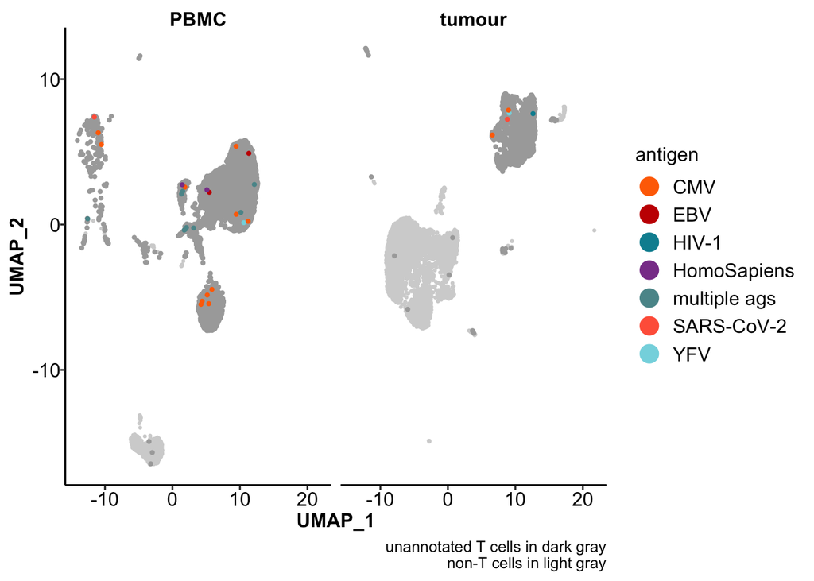

```r
#plotting onto the UMAP
ag.umap.p1 <- ggplot(seurat.data, aes(x = umap_1, y = umap_2)) +
  geom_point(data = seurat.data %>% filter(vdj_cell_type != "T"),
             size = 0.5,
             colour = "lightgray") +
  geom_point(data = seurat.data %>% filter(vdj_cell_type == "T", tcr_antigen_class == "none"),
             colour = "darkgray",
             size = 0.8) +
  geom_point(data = seurat.data %>% filter(vdj_cell_type == "T", tcr_antigen_class != "none"),
             aes(colour = tcr_antigen_class),
             size = 0.8) +
  scale_colour_futurama(name = "antigen") +
  theme_custom() +
  facet_grid(~ dataset) +
  guides(colour = guide_legend(override.aes = list(size = 5))) +
  labs(x = "UMAP_1",
       y = "UMAP_2",
       caption = "unannotated T cells in dark gray\nnon-T cells in light gray")
plot(ag.umap.p1)
```

[Back to generating antigen reference for TRBs](https://kjlj.github.io/scRNA-seq_VDJ/docs/generating_Ag_reference_for_TRB.html)

[Return to main page](https://kjlj.github.io/scRNA-seq_VDJ)